# Problem_set_Multi_variable

Jeswin

1 October 2017

```r
# loading libraries
library(ggplot2)
library(tidyr)
suppressMessages(library(dplyr))
suppressMessages(library(gridExtra))
```

```r
# laoding data
data('diamonds')
summary(diamonds)
```

```
##      carat               cut        color        clarity
##  Min.   :0.2000   Fair     : 1610   D: 6775   SI1    :13065
##  1st Qu.:0.4000   Good     : 4906   E: 9797   VS2    :12258
##  Median :0.7000   Very Good:12082   F: 9542   SI2    : 9194
##  Mean   :0.7979   Premium  :13791   G:11292   VS1    : 8171
##  3rd Qu.:1.0400   Ideal    :21551   H: 8304   VVS2   : 5066
##  Max.   :5.0100                     I: 5422   VVS1   : 3655
##                                     J: 2808   (Other): 2531
##      depth           table           price             x
##  Min.   :43.00   Min.   :43.00   Min.   :  326   Min.   : 0.000
##  1st Qu.:61.00   1st Qu.:56.00   1st Qu.:  950   1st Qu.: 4.710
##  Median :61.80   Median :57.00   Median : 2401   Median : 5.700
##  Mean   :61.75   Mean   :57.46   Mean   : 3933   Mean   : 5.731
##  3rd Qu.:62.50   3rd Qu.:59.00   3rd Qu.: 5324   3rd Qu.: 6.540
##  Max.   :79.00   Max.   :95.00   Max.   :18823   Max.   :10.740
##
##        y                z
##  Min.   : 0.000   Min.   : 0.000
##  1st Qu.: 4.720   1st Qu.: 2.910
##  Median : 5.710   Median : 3.530
##  Mean   : 5.735   Mean   : 3.539
##  3rd Qu.: 6.540   3rd Qu.: 4.040
##  Max.   :58.900   Max.   :31.800
##
```

## 1. Price Histograms with Facet and Color

Create a histogram of diamond prices. Facet the histogram by diamond color and use cut to color the histogram bars. Note that the plot in the linked image is using log(price) for the x-axis to adjust for positive skew in the data.

The plot should look something [like this](http://i.imgur.com/b5xyrOu.jpg).

Note: In the link, a color palette of type ‘qual’ was used to color the histogram using __ scale_fill_brewer(type = ‘qual’) __.

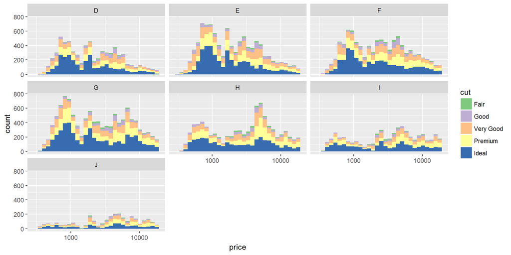

```r
ggplot(data = diamonds, aes(x=price, fill=cut))+
  geom_histogram() +
  scale_x_log10() +
   scale_fill_brewer(type='qual')+
  facet_wrap( ~ color)
```

## 2. Price vs. Table Colored by Cut

Create a scatterplot of diamond price vs. table and color the points by the cut of the diamond.

The plot should look something [like this](http://i.imgur.com/rQF9jQr.jpg)

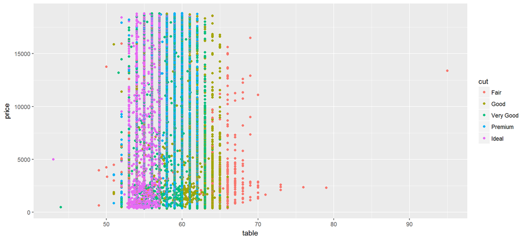

```r
ggplot(data=diamonds, aes(y=price, x=table, color = cut))+
  geom_point()
```

## 3. Typical Table Value

```r
table(diamonds$cut)
```

```
##
##      Fair      Good Very Good   Premium     Ideal
##      1610      4906     12082     13791     21551
```

```r
summary(diamonds$table)
```

```
##    Min. 1st Qu.  Median    Mean 3rd Qu.    Max.
##   43.00   56.00   57.00   57.46   59.00   95.00
```

```r
range(diamonds$table)
```

```
## [1] 43 95
```

## 4. Price vs. Volume and Diamond Clarity

Create a scatterplot of diamond price vs. volume (x * y * z) and color the points by the clarity of diamonds.

Use scale on the y-axis to take the log10 of price. You should also omit the top 1% of diamond volumes from the plot.

Note: Volume is a very rough approximation of a diamond’s actual volume.

The plot should look something [like this](http://i.imgur.com/excUpea.jpg) Note: In the link, a color palette of type ‘div’ was used to color the scatterplot using **scale_color_brewer(type = ‘div’)** [scale_color_brewer()](http://ggplot.yhathq.com/docs/scale_color_brewer.html)

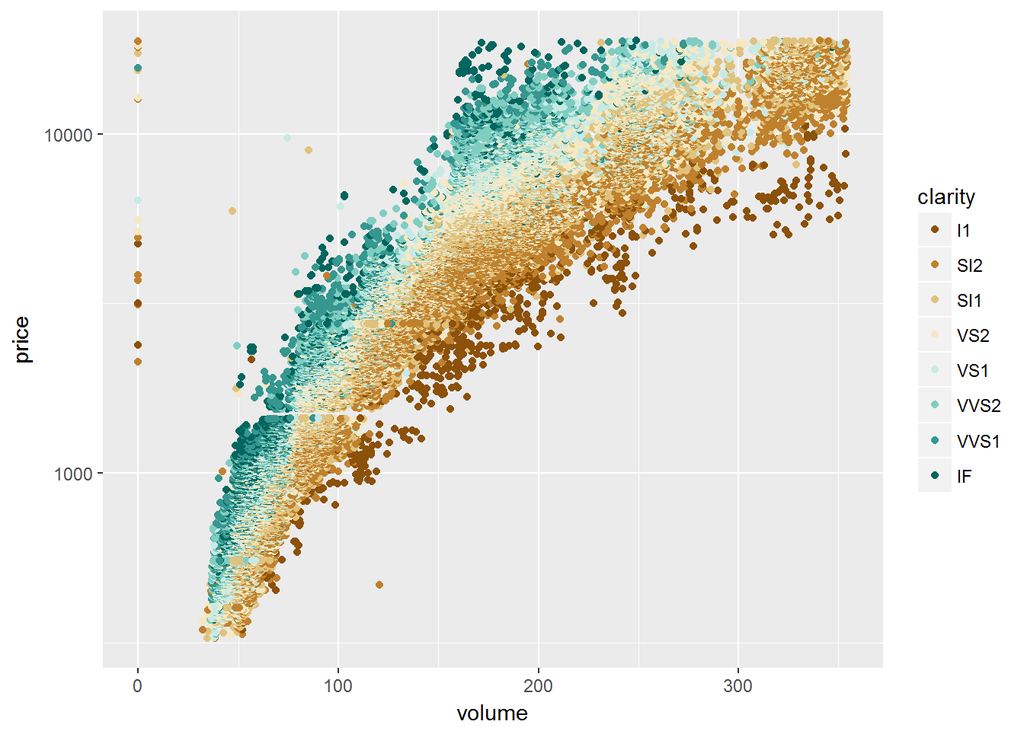

```r
diamonds$volume <- diamonds$x * diamonds$y * diamonds$z


ggplot(data = subset(diamonds, volume<quantile(volume,0.99)), aes(y=price, x=volume, color = clarity))+
  geom_point()+
  scale_y_log10()+
  scale_color_brewer(type = 'div')
```

## 5. Proportion of Friendships Initiated

```r
pf <- read.delim('pseudo_facebook.tsv')
```

Many interesting variables are derived from two or more others.

For example, we might wonder how much of a person’s network on a service like Facebook the user actively initiated. Two users with the same degree (or number of friends) might be very different if one initiated most of those connections on the service, while the other initiated very few. So it could be useful to consider this proportion of existing friendships that the user initiated. This might be a good predictor of how active a user is compared with their peers, or other traits, such as personality (i.e., is this person an extrovert?).

Your task is to create a new variable called ‘prop_initiated’ in the Pseudo-Facebook data set. The variable should contain the proportion of friendships that the user initiated.

```r
pf$prop_initiated <- pf$friendships_initiated/pf$friend_count
```

## 6. prop_initiated vs. tenure

Create a line graph of the median proportion of friendships initiated (‘prop_initiated’) vs. tenure and color the line segment by year_joined.bucket.

Recall, we created year_joined.bucket in Lesson 5 by first creating year_joined from the variable tenure. Then, we used the cut function on year_joined to create four bins or cohorts of users. (2004, 2009], (2009, 2011], (2011, 2012], (2012, 2014]

The plot should look something like [this](http://i.imgur.com/vNjPtDh.jpg). OR [this](http://i.imgur.com/IBN1ufQ.jpg).

```r
# Creating 2 new variables
pf$year_joined <- 2014 - ceiling(pf$tenure/365)
pf$year_joined.bucket <- cut(pf$year_joined, c(2004,2009,2011,2012,2014) )
table(pf$year_joined.bucket)
```

```
##
## (2004,2009] (2009,2011] (2011,2012] (2012,2014]
##        6669       15308       33366       43658
```

Creating the plot

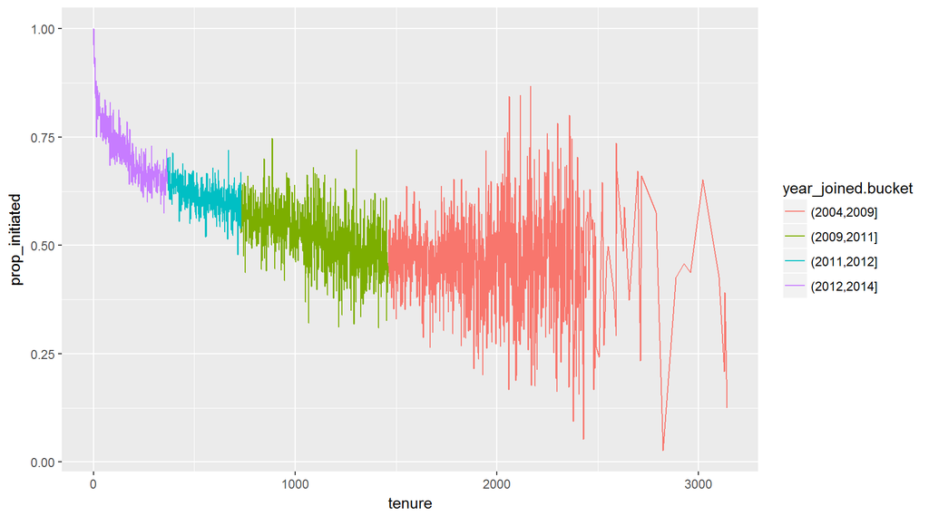

```r
p <- ggplot(data = subset(pf, !is.na(year_joined.bucket)), aes(x = tenure, y=prop_initiated, color=year_joined.bucket))+
  geom_line(stat = 'summary', fun.y = median)
p
```

## 7 Smoothing prop_initiated vs. tenure

Smooth the last plot you created of of prop_initiated vs tenure colored by year_joined.bucket. You can bin together ranges of tenure or add a smoother to the plot.

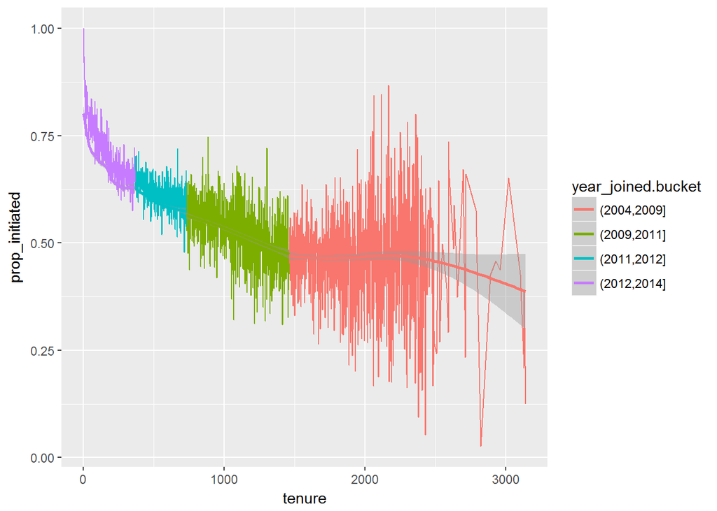

```r
# Done by adding a smoother
p + geom_smooth(linetype = 'solid')
```

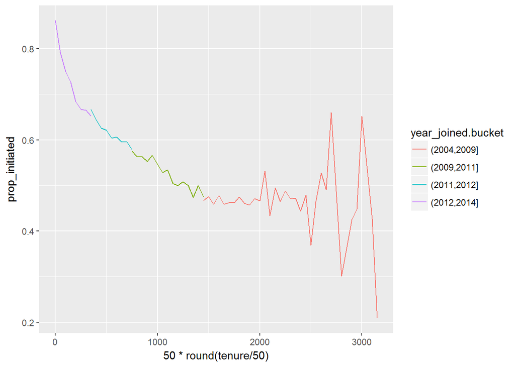

```r
# Doing by binning together  ranges of tenure

p1 <- ggplot(data = subset(pf, !is.na(year_joined.bucket)), aes(x = 50 * round(tenure/50) , y=prop_initiated, color=year_joined.bucket))+
  geom_line(stat = 'summary', fun.y = median)
p1
```

## 9 Largest Group Mean prop_initiated

```r
avg_pf_grp <- subset(pf, !is.na(prop_initiated)) %>%
  group_by(year_joined.bucket) %>%
  summarise(AVerage = mean(prop_initiated))

avg_pf_grp
```

```
## # A tibble: 5 x 2
##   year_joined.bucket   AVerage
##               <fctr>     <dbl>
## 1        (2004,2009] 0.4668151
## 2        (2009,2011] 0.5301298
## 3        (2011,2012] 0.5984577
## 4        (2012,2014] 0.6653892
## 5               <NA> 0.6168644
```

## 10. Price/Carat Binned, Faceted, & Colored

Create a scatter plot of the price/carat ratio of diamonds. The variable x should be assigned to cut. The points should be colored by diamond color, and the plot should be faceted by clarity.

[The plot should look something like this](http://i.imgur.com/YzbWkHT.jpg)

Note: In the link, a color palette of type ‘div’ was used to color the histogram using **scale_color_brewer(type = ‘div’)**.

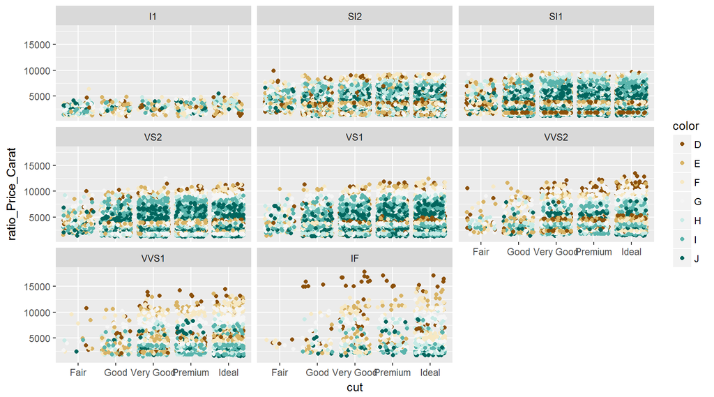

```r
# Insert the new variable
diamonds <- diamonds %>%
  mutate(ratio_Price_Carat = price/carat)

ggplot(data = diamonds, aes(x = cut, y = ratio_Price_Carat))+
  geom_jitter(aes(color = color, group = color))+
  facet_wrap( ~ clarity)+
  scale_color_brewer(type = 'div')
```

## 11 Gapminder Multivariate Analysis